# tutorial02-prediction

Nicholas R. Record

## R Markdown

This markdown document gives an example of how we could use TidyModels to make a forecast.

```r
library(tidymodels)  # for the parsnip package, along with the rest of tidymodels
# Helper packages
library(readr)       # for importing data
#library(broom.mixed) # for converting bayesian models to tidy tibbles
#library(dotwhisker)  # for visualizing regression results
```

## Loading the predictor data (North Atlantic Oscillation)

We’ll load the NAO data like we did in the last tutorial.

```r
nao <- read.csv('https://raw.githubusercontent.com/SeascapeScience/janplan2023/main/data/nao.csv')
```

Take a quick look at the data we just loaded

```r
nao
```

```
##     Year Jan.nao Feb.nao Mar.nao Apr.nao May.nao Jun.nao Jul.nao Aug.nao
## 1   1821  -99.99  -99.99  -99.99  -99.99  -99.99  -99.99   -2.62   -0.14
## 2   1822  -99.99  -99.99    2.99   -3.19    0.59   -0.86   -4.05   -0.19
## 3   1823   -3.39  -99.99  -99.99  -99.99    4.65   -0.83    0.58    2.90
## 4   1824   -0.16    0.25   -1.44    1.46    1.34   -3.94   -2.75   -0.08
## 5   1825   -0.23    0.21    0.33   -0.28    0.13    0.41   -0.92    1.43
## 6   1826   -3.05    4.87   -0.97    1.78   -1.20    0.83    1.89    2.72
## 7   1827   -0.45   -3.72    1.83   -0.83    1.20   -0.07    2.02   -3.56
## 8   1828    1.27    0.37   -0.18    0.04   -1.59   -1.33   -4.40   -2.54
## 9   1829   -2.48    0.32   -2.54    0.12    1.80   -0.10    0.33    0.77
## 10  1830   -2.33    1.20    3.58    3.08   -0.05   -0.85    3.19   -0.35
## 11  1831   -2.91    1.40    1.48   -3.15   -2.47   -1.36    2.71   -3.04
## 12  1832   -0.04    0.83    2.12   -1.51   -1.96   -3.62   -2.57    0.92
## 13  1833   -0.36    2.52   -2.89    2.02    0.69   -1.52    0.13   -1.74
## 14  1834    3.07    2.66    1.37   -2.38   -1.03    0.27   -0.73   -0.86
```

[output cut: 391 more lines]

## Loading in the herring data

Now let’s load in something we’re trying to forecast. This is a case where we’ll need to do some data cleaning.

```r
herring <- read.csv('../data/MaineHerring.csv')
```

And take a look at the data…

```r
herring
```

```
##    Year      Pounds Metric.Tons    Dollars Collection
## 1  1950 185,481,500      84,134  1,269,467 Commercial
## 2  1951  59,738,100      27,097    913,689 Commercial
## 3  1952 144,661,100      65,618  1,752,497 Commercial
## 4  1953 100,587,500      45,626  1,621,170 Commercial
## 5  1954 123,602,000      56,065  1,769,516 Commercial
## 6  1955  99,415,800      45,095  1,352,969 Commercial
## 7  1956 140,472,300      63,718  2,299,320 Commercial
## 8  1957 153,621,100      69,682  2,312,056 Commercial
## 9  1958 170,977,300      77,555  2,562,805 Commercial
## 10 1959 117,149,800      53,139  1,880,121 Commercial
## 11 1960 152,327,300      69,095  2,486,250 Commercial
## 12 1961  54,462,600      24,704  1,035,522 Commercial
## 13 1962 156,699,400      71,078  2,374,552 Commercial
## 14 1963 152,316,800      69,090  1,649,042 Commercial
```

[output cut: 58 more lines]

I noticed in the table that the data type for pounds, metric tons, and dollars is listed as “chr”. That means these aren’t seen by R as numbers, but as characters (i.e. text). It’s even more annoying because there are commas in the text. This can happen depending on the way the data you load in happens to be formatted.

It makes life difficult for doing data analysis, but we can fix it like this:

```r
herring$Metric.Tons <- as.numeric(gsub(",","",herring$Metric.Tons))
herring$Pounds <- as.numeric(gsub(",","",herring$Pounds))
herring$Dollars <- as.numeric(gsub(",","",herring$Dollars))
```

```r
herring
```

```
##    Year    Pounds Metric.Tons  Dollars Collection
## 1  1950 185481500       84134  1269467 Commercial
## 2  1951  59738100       27097   913689 Commercial
## 3  1952 144661100       65618  1752497 Commercial
## 4  1953 100587500       45626  1621170 Commercial
## 5  1954 123602000       56065  1769516 Commercial
## 6  1955  99415800       45095  1352969 Commercial
## 7  1956 140472300       63718  2299320 Commercial
## 8  1957 153621100       69682  2312056 Commercial
## 9  1958 170977300       77555  2562805 Commercial
## 10 1959 117149800       53139  1880121 Commercial
## 11 1960 152327300       69095  2486250 Commercial
## 12 1961  54462600       24704  1035522 Commercial
## 13 1962 156699400       71078  2374552 Commercial
## 14 1963 152316800       69090  1649042 Commercial
```

[output cut: 58 more lines]

We can also plot the data as a check that everything looks okay.

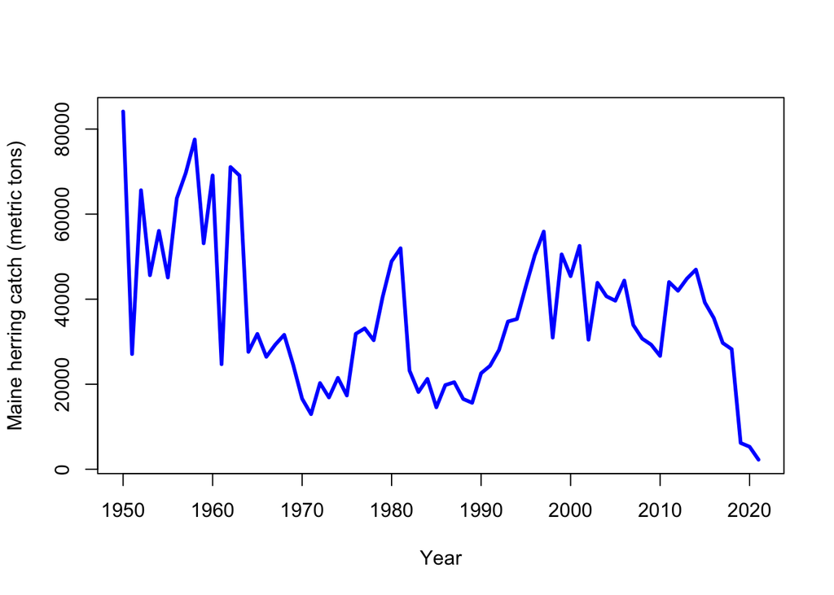

```r
plot(herring$Year,herring$Metric.Tons,
     type = 'l',
     xlab = "Year",
     ylab = "Maine herring catch (metric tons)",
     lwd = 3,
     col = "blue")
```

Now we can start to get an understanding of relationships within these datasets to help us understand if there’s any potential for prediction or forecasting.

We’re going to try to use the NAO (which is measured from climate data) to predict the herring catches in Maine. Let’s see if the January NAO variable has any relationship to the herring catches.

We want to plot one against the other, but right now, the NAO data goes from the 1800s to 2022, and the herring data goes from 1950 to 2021. Let’s line them up.

```r
alldata <- merge(nao,herring,by="Year")
```

And take a look at the merged data table…

```r
alldata
```

```
##    Year Jan.nao Feb.nao Mar.nao Apr.nao May.nao Jun.nao Jul.nao Aug.nao Sep.nao
## 1  1950    0.55    3.31    0.82    1.61   -1.73    1.26   -0.87   -0.28    1.51
## 2  1951    0.82    0.93   -2.01   -0.45   -2.11   -1.16    1.10    0.85   -0.22
## 3  1952    0.92    0.15   -1.14    2.79   -0.94    0.02   -0.79   -1.05   -3.02
## 4  1953   -0.02    0.54    1.25   -1.60   -0.75   -2.96    0.13    3.26    0.75
## 5  1954    0.10    0.57   -0.29   -0.26   -0.91   -0.94    0.88   -0.59    2.49
## 6  1955   -1.17   -2.21   -2.90    2.40    0.33   -0.18   -1.32    0.54    0.82
## 7  1956   -0.76   -2.96    0.01   -1.90    4.54    1.26    0.35   -3.15   -0.51
## 8  1957    2.53    1.08    0.42   -0.62   -0.84   -0.80   -0.48    0.70   -1.56
## 9  1958    0.37   -0.03   -1.28    1.79    1.10   -1.44   -0.20    0.98   -0.23
## 10 1959   -1.15    2.46    1.82    1.51   -2.22    1.51    0.29    0.02   -1.81
## 11 1960   -0.70   -1.00   -0.87    1.93    0.07   -0.41    0.18   -1.84    0.24
## 12 1961    1.46    4.06    2.08    0.71   -0.94    2.13    0.63    3.38    2.01
## 13 1962    2.44    0.77   -3.78    0.74   -0.10    1.41   -2.10    2.28    0.02
## 14 1963   -4.09   -1.90    2.79   -0.46    1.91   -1.77   -0.65   -0.96    0.94
```

[output cut: 131 more lines]

Another way to get a glimpse of a big data table like this is to turn it sideways using the glimpse() function.

```r
glimpse(alldata)
```

```
## Rows: 72
## Columns: 18
## $ Year        <int> 1950, 1951, 1952, 1953, 1954, 1955, 1956, 1957, 1958, 1959…
## $ Jan.nao     <dbl> 0.55, 0.82, 0.92, -0.02, 0.10, -1.17, -0.76, 2.53, 0.37, -…
## $ Feb.nao     <dbl> 3.31, 0.93, 0.15, 0.54, 0.57, -2.21, -2.96, 1.08, -0.03, 2…
## $ Mar.nao     <dbl> 0.82, -2.01, -1.14, 1.25, -0.29, -2.90, 0.01, 0.42, -1.28,…
## $ Apr.nao     <dbl> 1.61, -0.45, 2.79, -1.60, -0.26, 2.40, -1.90, -0.62, 1.79,…
## $ May.nao     <dbl> -1.73, -2.11, -0.94, -0.75, -0.91, 0.33, 4.54, -0.84, 1.10…
## $ Jun.nao     <dbl> 1.26, -1.16, 0.02, -2.96, -0.94, -0.18, 1.26, -0.80, -1.44…
## $ Jul.nao     <dbl> -0.87, 1.10, -0.79, 0.13, 0.88, -1.32, 0.35, -0.48, -0.20,…
## $ Aug.nao     <dbl> -0.28, 0.85, -1.05, 3.26, -0.59, 0.54, -3.15, 0.70, 0.98, …
## $ Sep.nao     <dbl> 1.51, -0.22, -3.02, 0.75, 2.49, 0.82, -0.51, -1.56, -0.23,…
## $ Oct.nao     <dbl> 0.78, -0.13, 0.42, 0.77, 2.09, -2.35, 1.23, 1.07, 1.65, 1.…
## $ Nov.nao     <dbl> 0.78, -0.97, -1.51, 3.25, 1.54, -2.14, 1.39, -1.59, 0.43, …
## $ Dec.nao     <dbl> -1.88, 2.54, -0.31, 0.15, 1.44, 0.51, 2.57, -0.12, -1.70, …
## $ NAO         <dbl> 0.49, -0.07, -0.37, 0.40, 0.51, -0.64, 0.17, -0.02, 0.12, …
## $ Pounds      <dbl> 185481500, 59738100, 144661100, 100587500, 123602000, 9941…
## $ Metric.Tons <dbl> 84134, 27097, 65618, 45626, 56065, 45095, 63718, 69682, 77…
## $ Dollars     <dbl> 1269467, 913689, 1752497, 1621170, 1769516, 1352969, 22993…
## $ Collection  <chr> "Commercial", "Commercial", "Commercial", "Commercial", "C…
```

Now we can make some simple plots of any column against any other column.

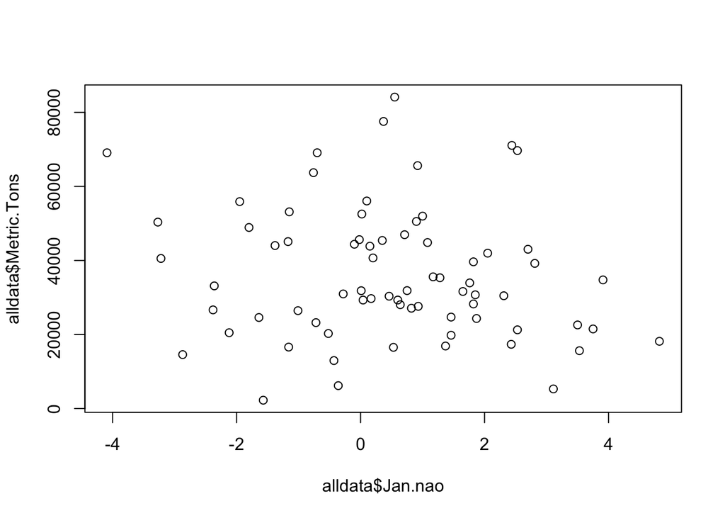

```r
plot(alldata$Jan.nao,alldata$Metric.Tons)
```

I don’t see a strong relationship there, but maybe if we use all of the data in the NAO table, we might be able to make a prediction. This is where we’ll get into modeling using the TidyModels package.

## Build and fit a model

We’re using a workflow from tidymodels, which has more examples at this site: https://www.tidymodels.org/start/models/. First we want to divide the data into some that we’ll use to train the model, and some that we’ll use to test how well the model did. Here we’ll use 80% of the data for training and 20% for testing.

```r
data_split <- initial_split(alldata, prop = 8/10)
data_test <- testing(data_split)
data_train <- training(data_split)
```

The next step is to build a “recipe” for the model. The first part tells it what to predict, based on which variables. Here, we’re predicting Metric.Tons as a function of the Jan, Feb, and Mar NAO values. The second part tells it what to use as the data table to work from–here the training data. This all sets the stage for our modeling.

```r
herring_recipe <- recipe(Metric.Tons ~ Jan.nao + Feb.nao + Mar.nao, data = data_train)
```

Now we can choose all kinds of different models to use. We’ll try linear regression. You have to choose an “engine” as well. This is just a way of refering to the code that runs in the background, that someone else has written to do whatever kind of modeling you’re doing. To see the engines, you can do this:

```r
show_engines("linear_reg")
```

```
## # A tibble: 7 × 2
##   engine mode
##   <chr>  <chr>
## 1 lm     regression
## 2 glm    regression
## 3 glmnet regression
## 4 stan   regression
## 5 spark  regression
## 6 keras  regression
## 7 brulee regression
```

We’ll choose “glm”. There are other options you can choose. For example, you could do a classification instead of a regression. We’ll talk about different model choices in class.

```r
lin_mod <- linear_reg() %>%
  set_mode("regression") %>%
  set_engine("glm")
lin_mod
```

```
## Linear Regression Model Specification (regression)
##
## Computational engine: glm
```

The next step is to combine the recipe and the model into a “workflow”.

```r
wflow <-
  workflow() %>%
  add_model(lin_mod) %>%
  add_recipe(herring_recipe)
```

Here’s what that workflow contains…

```r
wflow
```

```
## ══ Workflow ════════════════════════════════════════════════════════════════════
## Preprocessor: Recipe
## Model: linear_reg()
##
## ── Preprocessor ────────────────────────────────────────────────────────────────
## 0 Recipe Steps
##
## ── Model ───────────────────────────────────────────────────────────────────────
## Linear Regression Model Specification (regression)
##
## Computational engine: glm
```

Finally, we’ll put it all together to fit the data using the model and recipe we’ve built.

```r
herring_fit <- wflow %>%
  fit(data = data_train)
herring_fit
```

```
## ══ Workflow [trained] ══════════════════════════════════════════════════════════
## Preprocessor: Recipe
## Model: linear_reg()
##
## ── Preprocessor ────────────────────────────────────────────────────────────────
## 0 Recipe Steps
##
## ── Model ───────────────────────────────────────────────────────────────────────
##
## Call:  stats::glm(formula = ..y ~ ., family = stats::gaussian, data = data)
##
## Coefficients:
## (Intercept)      Jan.nao      Feb.nao      Mar.nao
##     37783.9      -1546.5       -210.9      -1629.5
##
## Degrees of Freedom: 56 Total (i.e. Null);  53 Residual
## Null Deviance:       1.643e+10
## Residual Deviance: 1.526e+10     AIC: 1278
```

## Assessing the model’s predictions

Now we can use the model fit to predict on the data that we held aside for testing.

```r
predict(herring_fit, data_test)
```

```
## # A tibble: 15 × 1
##     .pred
##     <dbl>
##  1 34899.
##  2 39595.
##  3 38187.
##  4 35664.
##  5 37628.
##  6 38207.
##  7 33305.
##  8 32441.
##  9 36961.
## 10 31713.
## 11 33418.
## 12 37186.
## 13 31665.
## 14 33942.
## 15 38933.
```

To compare the prediction to the actual value, you can plot them against each other. First you combine your fitted data to the testing data table. Then you can do a simple plot.

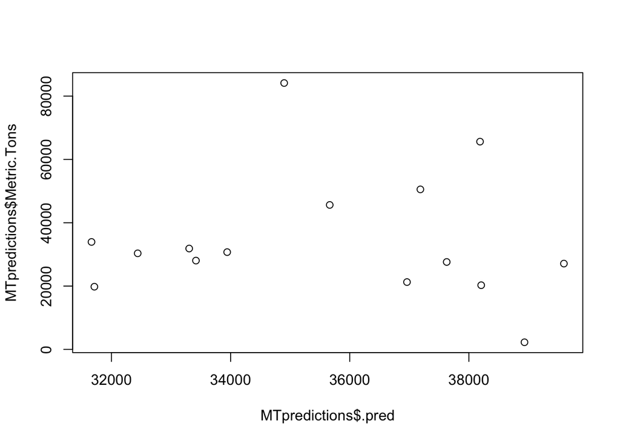

```r
MTpredictions <- augment(herring_fit, data_test)
plot(MTpredictions$.pred,MTpredictions$Metric.Tons)
```

Finally, you can look at the skill metrics of how the model did. RMSE is root mean square error, RSQ is the r-squared metric, and MAE is the mean absolute error. In this example, these are poor performance values. You would want RMSE and RAE to be small, and/or r-squared to be close to 1.

```r
fit_metrics <- metrics(MTpredictions, truth = Metric.Tons, estimate=.pred)
fit_metrics
```

```
## # A tibble: 3 × 3
##   .metric .estimator   .estimate
##   <chr>   <chr>            <dbl>
## 1 rmse    standard   19693.
## 2 rsq     standard       0.00216
## 3 mae     standard   14609.
```

## Turning it into a forecast

It looks like the NAO is not a great predictor of herring. But so far we’ve used a given year NAO value to predict that same year’s herring catch. If we were really going to forecast, we would need to use the NAO value(s) to predict the following year’s herring catch. We can do this by shifting all of the herring catch data by a year. Let’s build a new data table from the herring data, but shift the years by one.

```r
herring_lag <- herring # Copies the 'herring' table to a new variable
herring_lag$Year <- herring_lag$Year - 1 # Subtracts 1 from the year
lagdata <- merge(nao,herring_lag,by="Year") # Makes a combined data table with all data, only now the herring data is lagged by a year
```

Now we can walk through the same modeling steps with this new data table. I’ll combine them together in one block.

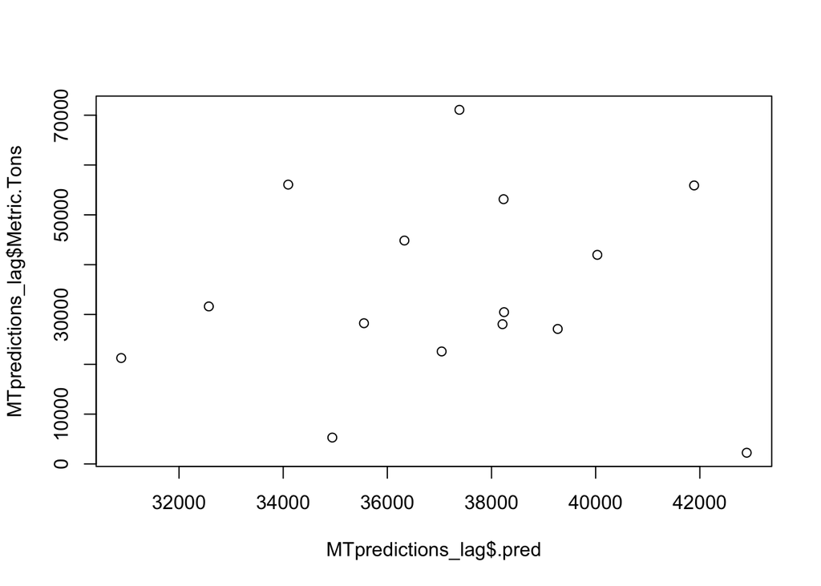

```r
data_split <- initial_split(lagdata, prop = 8/10)
data_test <- testing(data_split)
data_train <- training(data_split)
herring_lag_recipe <- recipe(Metric.Tons ~ Jan.nao + Feb.nao + Mar.nao + NAO, data = data_train)
lin_mod <- linear_reg() %>%
  set_mode("regression") %>%
  set_engine("glm")
wflow <-
  workflow() %>%
  add_model(lin_mod) %>%
  add_recipe(herring_lag_recipe)
herring_lag_fit <- wflow %>%
  fit(data = data_train)
MTpredictions_lag <- augment(herring_lag_fit, data_test)
plot(MTpredictions_lag$.pred,MTpredictions_lag$Metric.Tons)
```

```r
fit_metrics_lag <- metrics(MTpredictions_lag, truth = Metric.Tons, estimate=.pred)
fit_metrics_lag
```

```
## # A tibble: 3 × 3
##   .metric .estimator   .estimate
##   <chr>   <chr>            <dbl>
## 1 rmse    standard   18818.
## 2 rsq     standard       0.00175
## 3 mae     standard   15185.
```

The last thing we’ll do is think about this in a forecasting context– in other words, what if we want to train our data from the early part of the time series, and test it on the later part? A random split of the data won’t accomplish this. So we need to split the data by time. All you have to do is replace “initial_split” with “initial_time_split”.

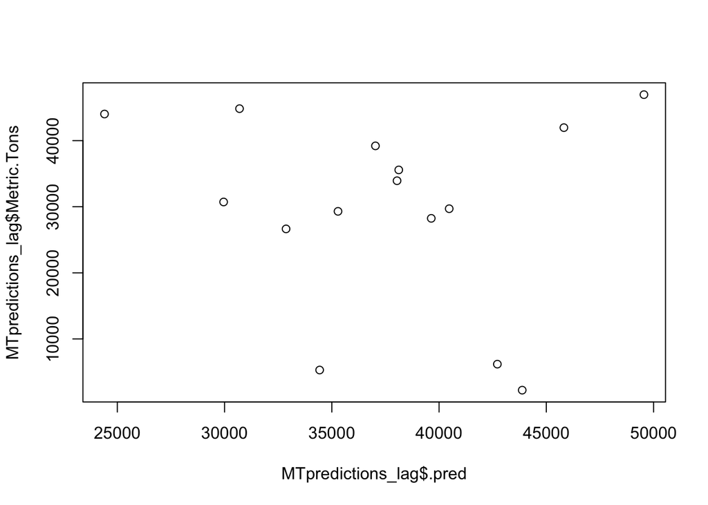

```r
data_split <- initial_time_split(lagdata, prop = 8/10)
data_test <- testing(data_split)
data_train <- training(data_split)
herring_lag_recipe <- recipe(Metric.Tons ~ Jan.nao + Feb.nao + Mar.nao + NAO, data = data_train)
lin_mod <- linear_reg() %>%
  set_mode("regression") %>%
  set_engine("glm")
wflow <-
  workflow() %>%
  add_model(lin_mod) %>%
  add_recipe(herring_lag_recipe)
herring_lag_fit <- wflow %>%
  fit(data = data_train)
MTpredictions_lag <- augment(herring_lag_fit, data_test)
plot(MTpredictions_lag$.pred,MTpredictions_lag$Metric.Tons)
```

```r
fit_metrics_lag <- metrics(MTpredictions_lag, truth = Metric.Tons, estimate=.pred)
fit_metrics_lag
```

```
## # A tibble: 3 × 3
##   .metric .estimator  .estimate
##   <chr>   <chr>           <dbl>
## 1 rmse    standard   18021.
## 2 rsq     standard       0.0219
## 3 mae     standard   12763.
```

The cool thing about doing it this way is that we can plot what would have been predicted against what actually happened.

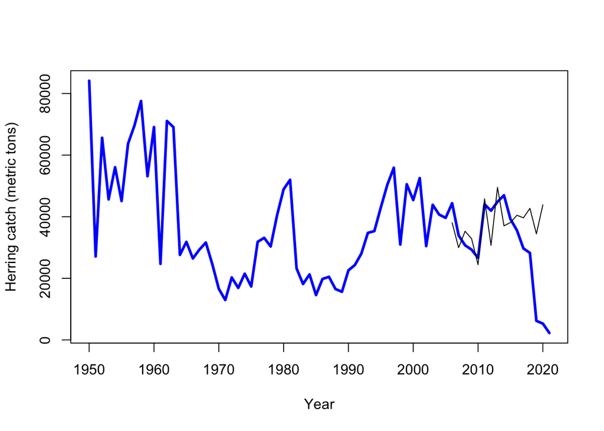

```r
plot(alldata$Year,alldata$Metric.Tons,
     type='l',
     col='blue',
     lwd=3,
     xlab='Year',
     ylab='Herring catch (metric tons)')
lines(MTpredictions_lag$Year,MTpredictions_lag$.pred)
```

## Assignment

Produce a new forecast. Either replace the herring data with a different time series, or replace the NAO with different predictor variables (or both). Follow the steps above, and see if you can get a better forecast.

Here are some of the data sources mentioned earlier:

- Global fish stock time series
  - http://www.seaaroundus.org
- Commercial fishery landings data
  - https://www.fisheries.noaa.gov/foss/f?p=215:200:4272106129122:Mail::::
  - https://www.maine.gov/dmr/commercial-fishing/landings/historical-data.html
- NOAA climate indices
  - https://psl.noaa.gov/data/climateindices/list/
- Satellite ocean data
  - https://oceancolor.gsfc.nasa.gov/
- Ocean ecosystem indicators
  - https://noaa-edab.github.io/tech-doc/